# EST_MAT_TALLER3

2025-05-01

## Punto 1

En un bucle generar 10000 muestras aleatorias de tamaño n = 100 de una variable uniforme con parámetro 8 (ver función runif)

## Punto 2

Calcular ˆθ1, ˆθ2, ˆθ3 para cada muestra en 3 vectores que llamará theta1, theta2 y theta3.

```r
set.seed(123) #Semilla para reproductibidad
n <- 100 #Tamaño de muestra
num_muestras <- 10000 #Número muestras

#Vectores para los estimadores
theta1 <- numeric(num_muestras)
theta2 <- numeric(num_muestras)
theta3 <- numeric(num_muestras)

#Bucle para generar las muestras
for (i in 1:num_muestras) {
  muestra <- runif(n, min = 0, max = 8)
  theta1[i] <- 2 * mean(muestra)
  theta2[i] <- max(muestra)
  theta3[i] <- (n + 1)* min(muestra)
}
```

## Punto 3

Dibuje los histogramas de los 3 estimadores. Utilice par(mfrow=c(1,3)) para que queden los 3 en la misma figura.

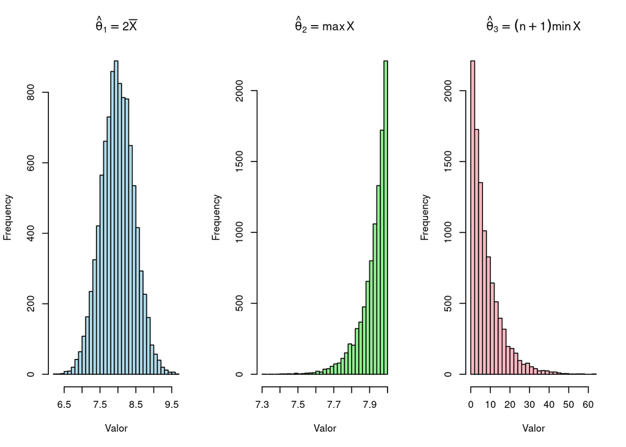

```r
par(mfrow = c(1, 3))

hist(theta1, main = expression(hat(theta)[1] == 2 * bar(X)), col = "lightblue", xlab = "Valor", breaks = 40)
hist(theta2, main = expression(hat(theta)[2] == max(X)), col = "lightgreen", xlab = "Valor", breaks = 40)
hist(theta3, main = expression(hat(theta)[3] == (n+1) * min(X)), col = "lightpink", xlab = "Valor", breaks = 40)
```

```r
par(mfrow = c(1,1))
```

## Punto 4

Unir los 3 vectores con los estimadores en una matriz. Utilice tidyverse.

```r
library(tidyverse)
estimadores <- tibble(
  theta1 = theta1,
  theta2 = theta2,
  theta3 = theta3
)
```

## Punto 5

```r
# Valor real de theta
theta_real <- 8

# Funciones auxiliares para hallar el sesgo y varianza más rápido
sesgo <- function(est, real) mean(est) - real
varianza <- function(est) var(est)

# Calcular sesgo y varianza
resultados <- tibble(
  Estimador = c("theta1", "theta2", "theta3"),
  Sesgo = c(sesgo(theta1, theta_real),
            sesgo(theta2, theta_real),
            sesgo(theta3, theta_real)),
  Varianza = c(varianza(theta1),
               varianza(theta2),
               varianza(theta3))
)

print(resultados)
```

```
## # A tibble: 3 × 3
##   Estimador    Sesgo Varianza
##   <chr>        <dbl>    <dbl>
## 1 theta1    -0.00754  0.210
## 2 theta2    -0.0800   0.00630
## 3 theta3    -0.0524  61.8
```

## Punto 6

Haga una gráfica de cajas y bigotes de la matriz, que incluya los 3 estimadores y trace una línea horizontal mostrando el valor real del parámetro θ.

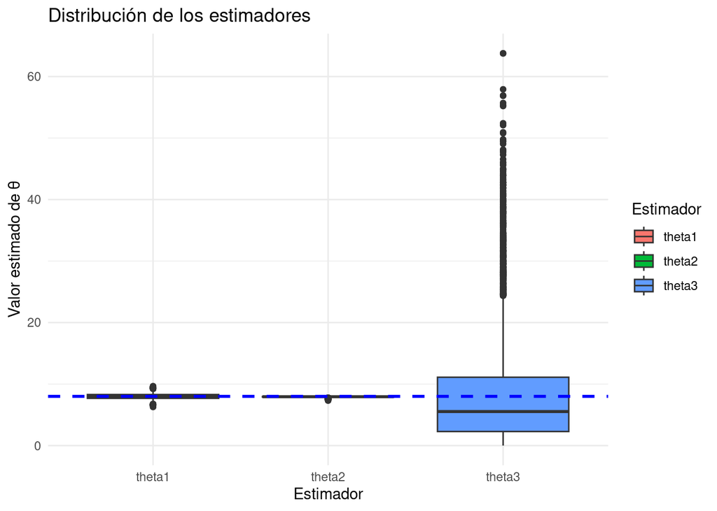

```r
# Convertimos a formato largo
estimadores_long <- estimadores %>%
  pivot_longer(cols = everything(), names_to = "Estimador", values_to = "Valor")

# Gráfico
ggplot(estimadores_long, aes(x = Estimador, y = Valor, fill = Estimador)) +
  geom_boxplot() +
  geom_hline(yintercept = 8, linetype = "dashed", color = "blue", size = 1) +
  labs(title = "Distribución de los estimadores",
       y = "Valor estimado de θ") +
  theme_minimal()
```

## Punto 7

Concluya y agregue comentarios que muestren su entendimiento sobre los estimadores.

En primer lugar, podemos observar que la caja del estimador theta 1 se encuentra centrada en el valor real de theta y como la caja no tiene tanta altura muestra que esta presenta muy poca varianza, por lo que es bastante preciso. Así, podríamos decir que el esgtimador theta 1 es preciso, consistente y eficiente.

En segundo lugar, hablando sobre el estimador theta 2. Su respectiva caja se ecnuentra un poco abajo del valor real de theta, pero es más estrecha que theta 1, es decir, tiene menos varianza, es más precisa, aunque ya se probó que es sesgado. Este estimador puede ser útil si no es relevante un leve sesgo.

En tercer lugar, el estimador theta 3 se representa en una caja más amplia que los demás estimadores, es decir, su varianza es alta con respecto a theta 1 y theta 2. Además, la mediana de theta 3 está por debajo del valor real. Aunque teóricamente theta 3 es insesgado, este estimador presenta alta varianza, por lo que es inestable, asi que no se recomendaría para estimar theta.